# Interactive Programming with R Markdown

January, 2019

## Outline

- Basics
- Polish reports: what to present?
- Dynamic reports
- Bookdown and slides presentation
- Examples in GitHub: https://github.com/lizzyhuang/RLadies_Jan2019

## Reference

- R Markdown Cheat Sheet

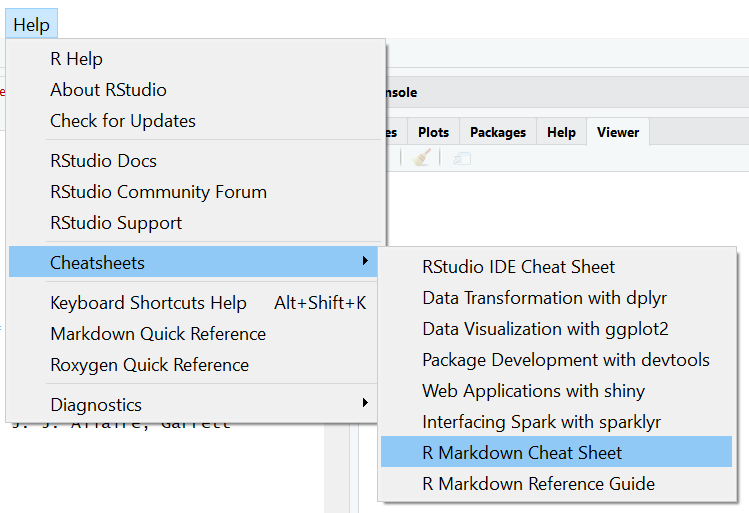

- *R Markdown: The Definitive Guide*, Yihui Xie, J. J. Allaire, Garrett Grolemund https://bookdown.org/yihui/rmarkdown/

## R Markdown Examples

- HTML, PDF, word documents
- Slide presentations
- Websites
- Books
- Emails
- Journal articles and thesis
- ……

## Basics

- Get started: start a R Markdown file in RStudio

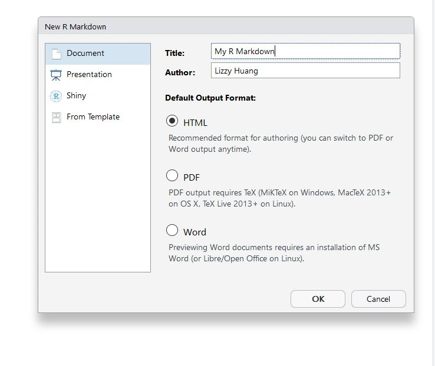

## Basics

[figure not shown]

YAML header

**Knit** button

## Polish Reports: What to Present?

- **An example:**

We here define a function

\[ f(x) = x + 1, \]

and the code to implement this function is

```r
my_function = function(x) {
  return (x + 1)
}
```

- **Another example:**

We here define a function \(f(x) = x + 1\), and the code to implement this function is `my_function = function(x) {return (x + 1)}`.

## What to Present?

- Goal
  - Audience-friendly
- Consider
  - R code chunk options
  - Organize document: table of contents and tabs
  - Other output formats:
    - Word document Set `output: word_documentation` in YAML header
    - PDF document (required MikTex or tinytex) Set `output: pdf_documentation` in YAML header

## Dynamic Reports

- Flexibility
- Collaboration
  - Parametrized your report using `params` in YAML header
  - Adopt a "child" R Markdown file

  ````
  ```{r get-child, child='Child.Rmd'}
  ```
  ````

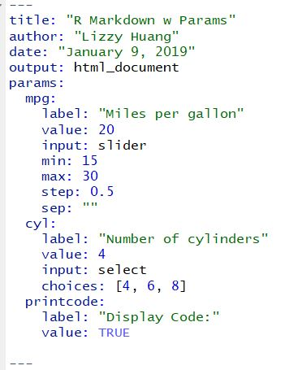

## Bookdown

- Get started (Tex required to build book)

`File -> New Project... -> New Directory -> Book project using bookdown`

- index.Rmd file
  - YAML
  - Load libraries and data
  - Pre-define LaTex shortcuts
- Book-level elements
- Reference `{#label}` with `\@ref(label)`
- Numbering for chapters and sections
  - Bookdown merges `.Rmd` files by the order of file names

## Presentations

- R Presentation

[figure not shown]

- Other formats
  - ioslides
  - slidy
  - beamer (require Tex installed)
  - PowerPoint (require pandoc version >= 2.0.5)
  - xaringan